# R Notebook

```r
scores_loc <- read.table("/Users/jialincheoh/Library/CloudStorage/Box-Box/NSF IronHacks App 2016 - 2019/05 Experiments 2017/01 Hack Spring 2017/01 Summary Spring 2017/02 Data/processed-data/overall_score_click_result.csv", header=TRUE, sep = ",")
scores_loc
```

| X | Student | Group | user.requirement.phase5 | infovis.phase5 | novelty.phase5 | total.phase5 | tech.phase5 | tech.phase4 | user.requirement.phase4 | infovis.phase4 | novelty.phase4 | total.phase4 | tech.phase3 | user.requirement.phase3 | infovis.phase3 | novelty.phase3 | total.phase3 | tech.phase2 | user.requirement.phase2 | infovis.phase2 | novelty.phase2 | total.phase2 | tech.phase1 | user.requirement.phase1 | infovis.phase1 | novelty.phase1 | total.phase1 | improve.ur.12 | improve.ur.23 | … |
| --- | --- | --- | --- | --- | --- | --- | --- | --- | --- | --- | --- | --- | --- | --- | --- | --- | --- | --- | --- | --- | --- | --- | --- | --- | --- | --- | --- | --- | --- | --- |
| 0 | fffeelipe | 0 | 20 | 29.17 | 50.00 | 199.17 | 100.0 | 100.0 | 20 | 29.17 | 43.75 | 192.92 | 75.0 | 60 | 37.50 | 0.00 | 172.50 | 75.0 | 60 | 37.50 | 0.00 | 172.50 | 50.0 | 20 | 29.17 | 0.00 | 99.17 | 40 | 0 | … |
| 1 | mnguzmanc | 0 | 60 | 75.00 | 67.50 | 290.00 | 87.5 | 87.5 | 20 | 37.50 | 100.00 | 245.00 | 100.0 | 20 | 41.67 | 75.00 | 236.67 | 87.5 | 20 | 37.50 | 75.00 | 220.00 | 87.5 | 0 | 0.00 | 0.00 | 87.50 | 20 | 0 | … |
| 2 | jmcuestasb | 0 | 100 | 54.17 | 25.00 | 254.17 | 75.0 | 62.5 | 100 | 58.33 | 0.00 | 220.83 | 62.5 | 20 | 50.00 | 0.00 | 132.50 | 62.5 | 20 | 33.33 | 25.00 | 140.83 | 50.0 | 0 | 0.00 | 0.00 | 50.00 | 20 | 0 | … |
| 3 | katherinsb | 0 | 20 | 37.50 | 16.67 | 136.67 | 62.5 | 37.5 | 20 | 45.83 | 25.00 | 128.33 | 0.0 | 0 | 0.00 | 0.00 | 0.00 | 12.5 | 0 | 0.00 | 0.00 | 12.50 | 0.0 | 0 | 0.00 | 0.00 | 0.00 | 0 | 0 | … |
| 4 | jjrodriguezn | 0 | 60 | 58.33 | 87.50 | 255.83 | 50.0 | 37.5 | 40 | 54.17 | 0.00 | 131.67 | 37.5 | 20 | 45.83 | 0.00 | 103.33 | 62.5 | 20 | 29.17 | 0.00 | 111.67 | 0.0 | 0 | 0.00 | 0.00 | 0.00 | 20 | 0 | … |
| 5 | DglyP | 0 | 20 | 25.00 | 50.00 | 195.00 | 100.0 | 87.5 | 0 | 25.00 | 50.00 | 162.50 | 50.0 | 40 | 50.00 | 0.00 | 140.00 | 37.5 | 40 | 45.83 | 0.00 | 123.33 | 0.0 | 0 | 0.00 | 0.00 | 0.00 | 40 | 0 | … |
| 6 | cap182 | 0 | 20 | 29.17 | 0.00 | 49.17 | 0.0 | 0.0 | 20 | 29.17 | 0.00 | 49.17 | 0.0 | 20 | 29.17 | 0.00 | 49.17 | 12.5 | 0 | 20.83 | 0.00 | 33.33 | 0.0 | 40 | 33.33 | 75.00 | 148.33 | -40 | 20 | … |
| 7 | annumumozme | 0 | 40 | 37.50 | 60.00 | 237.50 | 100.0 | 75.0 | 0 | 0.00 | 0.00 | 0.00 | 62.5 | 0 | 0.00 | 0.00 | 0.00 | 37.5 | 20 | 45.83 | 0.00 | 103.33 | 37.5 | 0 | 0.00 | 0.00 | 37.50 | 20 | -20 | … |
| 8 | Judgarciani | 0 | 100 | 58.33 | 66.67 | 325.00 | 100.0 | 75.0 | 80 | 87.50 | 0.00 | 242.50 | 62.5 | 80 | 79.17 | 0.00 | 221.67 | 37.5 | 20 | 29.17 | 0.00 | 86.67 | 0.0 | 0 | 0.00 | 0.00 | 0.00 | 20 | 60 | … |
| 9 | sacastroc | 0 | 20 | 50.00 | 68.75 | 226.25 | 87.5 | 87.5 | 20 | 50.00 | 62.50 | 220.00 | 100.0 | 20 | 33.33 | 62.50 | 215.83 | 87.5 | 20 | 33.33 | 62.50 | 203.33 | 50.0 | 0 | 25.00 | 0.00 | 75.00 | 20 | 0 | … |

[output cut: 154 more lines]

```r
lmLength <- residuals(lm(improve.sum.novel ~ Group, data=scores_loc))
shapiro.test(lmLength)
```

```
    Shapiro-Wilk normality test

data:  lmLength
W = 0.94543, p-value = 5.814e-06
```

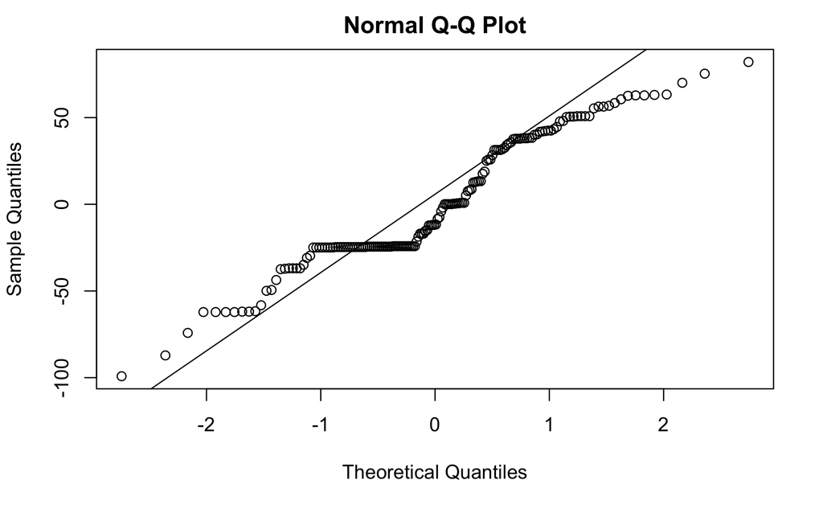

```r
qqnorm(lmLength)
qqline(lmLength)
```

```r
lmLength <- lm(total.phase5 ~ novelty.phase5, data=scores_loc)
summary(lmLength)
```

```
Call:
lm(formula = total.phase5 ~ novelty.phase5, data = scores_loc)

Residuals:
    Min      1Q  Median      3Q     Max
-82.401 -44.414  -3.153  40.374 121.769

Coefficients:
               Estimate Std. Error t value Pr(>|t|)
(Intercept)     58.1416     6.0660   9.585   <2e-16 ***
novelty.phase5   2.9704     0.1087  27.337   <2e-16 ***
---
Signif. codes:  0 ‘***’ 0.001 ‘**’ 0.01 ‘*’ 0.05 ‘.’ 0.1 ‘ ’ 1

Residual standard error: 46.57 on 162 degrees of freedom
Multiple R-squared:  0.8218,    Adjusted R-squared:  0.8207
F-statistic: 747.3 on 1 and 162 DF,  p-value: < 2.2e-16
```

> We want to answer the following questions: 1. At the population level, are there any difference in novelty score phase 5 for the 4 groups? 2. At the population level, are there any difference in novelty score phase 5 for lines of codes added? 3. Do the effects of groups on the novelty score phase 5 differ across the number of lines of codes added?

```r
model<-lm(novelty.phase5~factor(Group)*factor(sum.add.loc), data=scores_loc)
anova(model)
```

```
Analysis of Variance Table

Response: novelty.phase5
                                  Df Sum Sq Mean Sq F value  Pr(>F)
factor(Group)                      3   3553 1184.41  1.4166 0.24891
factor(sum.add.loc)               85 117880 1386.82  1.6586 0.02703 *
factor(Group):factor(sum.add.loc) 25  20472  818.89  0.9794 0.50837
Residuals                         50  41806  836.12
---
Signif. codes:  0 ‘***’ 0.001 ‘**’ 0.01 ‘*’ 0.05 ‘.’ 0.1 ‘ ’ 1
```

## Investigating the novelty score phase 5 across 4 groups.

```r
library(Rmisc)
library(ggplot2)
stats <- summarySE(scores_loc, measurevar="novelty.phase5", groupvars=c("Group"))
stats
```

| Group | N | novelty.phase5 | sd | se | ci |
| --- | --- | --- | --- | --- | --- |
| 0 | 40 | 38.14600 | 33.08875 | 5.231790 | 10.58229 |
| 1 | 41 | 46.97171 | 35.18839 | 5.495503 | 11.10683 |
| 2 | 42 | 42.79786 | 33.15144 | 5.115378 | 10.33072 |
| 3 | 41 | 50.69098 | 32.73753 | 5.112744 | 10.33324 |

> Highest mean is full transparency group, followed by performance transparency, followed by solution transparency and followed by no transparency.

## Investigating the user requirement score phase 5 across 4 groups.

```r
library(Rmisc)
library(ggplot2)
stats <- summarySE(scores_loc, measurevar="user.requirement.phase5", groupvars=c("Group"))
stats
```

| Group | N | user.requirement.phase5 | sd | se | ci |
| --- | --- | --- | --- | --- | --- |
| 0 | 40 | 32.00000 | 32.91013 | 5.203549 | 10.52517 |
| 1 | 41 | 38.53659 | 35.88600 | 5.604451 | 11.32702 |
| 2 | 42 | 37.61905 | 37.53434 | 5.791675 | 11.69652 |
| 3 | 41 | 46.34146 | 37.26635 | 5.820025 | 11.76271 |

> Highest mean is full transparency group, followed by performance transparency, followed by solution transparency and followed by no transparency.

```r
library(Rmisc)
library(ggplot2)
stats <- summarySE(scores_loc, measurevar="tech.phase5", groupvars=c("Group"))
stats
```

| Group | N | tech.phase5 | sd | se | ci |
| --- | --- | --- | --- | --- | --- |
| 0 | 40 | 53.43750 | 36.46955 | 5.766342 | 11.663528 |
| 1 | 41 | 64.02439 | 30.64350 | 4.785711 | 9.672284 |
| 2 | 42 | 69.94048 | 31.60584 | 4.876887 | 9.849074 |
| 3 | 41 | 73.78049 | 27.64237 | 4.317013 | 8.725008 |

```r
library(Rmisc)
library(ggplot2)
stats <- summarySE(scores_loc, measurevar="infovis.phase5", groupvars=c("Group"))
stats
```

| Group | N | infovis.phase5 | sd | se | ci |
| --- | --- | --- | --- | --- | --- |
| 0 | 40 | 35.20850 | 22.66421 | 3.583526 | 7.248366 |
| 1 | 41 | 44.51220 | 24.42834 | 3.815065 | 7.710534 |
| 2 | 42 | 42.16238 | 22.82571 | 3.522084 | 7.112993 |
| 3 | 41 | 47.05195 | 22.46194 | 3.507966 | 7.089865 |

## Investigating the total lines of codes added BETWEEN phase 1 and phase 5 across 4 groups.

```r
library(Rmisc)
library(ggplot2)
stats <- summarySE(scores_loc, measurevar="sum.add.loc", groupvars=c("Group"))
stats
```

| Group | N | sum.add.loc | sd | se | ci |
| --- | --- | --- | --- | --- | --- |
| 0 | 40 | 71.12500 | 104.3505 | 16.49927 | 33.37292 |
| 1 | 41 | 67.82927 | 111.3961 | 17.39715 | 35.16095 |
| 2 | 42 | 53.64286 | 105.6875 | 16.30793 | 32.93454 |
| 3 | 41 | 112.26829 | 177.6567 | 27.74531 | 56.07537 |

## Independent two-sample t-test on novelty score phase 5 and user requirment score phase 5

> The independent samples t-test is used when two separate sets of independent and identically distributed samples are obtained, one from each of the two populations being compared. For example, in evaluating the effect of an intervention, we enroll 100 participants and randomly assign 50 to the treatment group and the other 50 to the control group. In this case, we have two independent samples and should use the independent two-sample t-test.

> Welch’s t test (unpooled two independent sample t test) When the two population variances of the two groups are not equal (the two sample sizes may or may not be equal).

> In R, the function t.test() can be used to conduct a t test. The following code conducts the Welch’s t test. Note that alternative = “greater” sets the alternative hypothesis. The other options include two.sided and less.

> > Comment - more reliable when the two samples have unequal variances and/or unequal sample sizes

```r
var(scores_loc$novelty.phase5[scores_loc$Group==0])
```

```
[1] 1094.865
```

```r
var(scores_loc$novelty.phase5[scores_loc$Group==3])
```

```
[1] 1071.746
```

# Interpretation:

```r
training<-scores_loc$tech.phase5[scores_loc$Group==0]
control<-scores_loc$tech.phase5[scores_loc$Group==3]
mean(training, na.rm=T)-mean(control, na.rm=T)
```

```
[1] -20.34299
```

```r
t.test(training, control, alternative = 'less')
```

```
    Welch Two Sample t-test

data:  training and control
t = -2.8241, df = 72.702, p-value = 0.003057
alternative hypothesis: true difference in means is less than 0
95 percent confidence interval:
      -Inf -8.341711
sample estimates:
mean of x mean of y
 53.43750  73.78049
```

```r
training<-scores_loc$infovis.phase5[scores_loc$Group==0]
control<-scores_loc$infovis.phase5[scores_loc$Group==3]
mean(training, na.rm=T)-mean(control, na.rm=T)
```

```
[1] -11.84345
```

```r
t.test(training, control, alternative = 'less')
```

```
    Welch Two Sample t-test

data:  training and control
t = -2.3617, df = 78.909, p-value = 0.01033
alternative hypothesis: true difference in means is less than 0
95 percent confidence interval:
      -Inf -3.496969
sample estimates:
mean of x mean of y
 35.20850  47.05195
```

```r
training<-scores_loc$novelty.phase5[scores_loc$Group==0]
control<-scores_loc$novelty.phase5[scores_loc$Group==3]
mean(training, na.rm=T)-mean(control, na.rm=T)
```

```
[1] -12.54498
```

```r
t.test(training, control, alternative = 'less')
```

```
    Welch Two Sample t-test

data:  training and control
t = -1.7149, df = 78.9, p-value = 0.04514
alternative hypothesis: true difference in means is less than 0
95 percent confidence interval:
       -Inf -0.3696249
sample estimates:
mean of x mean of y
 38.14600  50.69098
```

## Interpretation:

> Significant for Group 0 and Group 3 ( < 0.05 ), novelty score phase 5

```r
training<-scores_loc$user.requirement.phase5[scores_loc$Group==0]
control<-scores_loc$user.requirement.phase5[scores_loc$Group==3]
mean(training, na.rm=T)-mean(control, na.rm=T)
```

```
[1] -14.34146
```

```r
t.test(training, control, alternative = 'less')
```

```
    Welch Two Sample t-test

data:  training and control
t = -1.837, df = 78.236, p-value = 0.035
alternative hypothesis: true difference in means is less than 0
95 percent confidence interval:
     -Inf -1.34617
sample estimates:
mean of x mean of y
 32.00000  46.34146
```

## Interpretation:

> Significant for Group 0 and Group 3 ( < 0.05 ), user requirement score phase 5

```r
training<-scores_loc$improve.sum.novel[scores_loc$Group==2]
control<-scores_loc$improve.sum.novel[scores_loc$Group==3]
mean(training, na.rm=T)-mean(control, na.rm=T)
```

```
[1] -12.72769
```

```r
t.test(training, control, alternative = 'less')
```

```
    Welch Two Sample t-test

data:  training and control
t = -1.5828, df = 79.716, p-value = 0.05871
alternative hypothesis: true difference in means is less than 0
95 percent confidence interval:
    -Inf 0.65425
sample estimates:
mean of x mean of y
 18.09548  30.82317
```

```r
interaction <- lm(improve.sum.novel ~ Group, data = scores_loc)

summary(interaction)
```

```
Call:
lm(formula = improve.sum.novel ~ Group, data = scores_loc)

Residuals:
   Min     1Q Median     3Q    Max
-99.18 -24.67 -11.80  36.26  82.07

Coefficients:
            Estimate Std. Error t value Pr(>|t|)
(Intercept)  24.1821     4.9199   4.915 2.16e-06 ***
Group         0.2435     2.6207   0.093    0.926
---
Signif. codes:  0 ‘***’ 0.001 ‘**’ 0.01 ‘*’ 0.05 ‘.’ 0.1 ‘ ’ 1

Residual standard error: 37.34 on 162 degrees of freedom
Multiple R-squared:  5.331e-05, Adjusted R-squared:  -0.006119
F-statistic: 0.008637 on 1 and 162 DF,  p-value: 0.9261
```

```r
training<-scores_loc$tech.phase5[scores_loc$Group==0]
control<-scores_loc$tech.phase5[scores_loc$Group==2]
mean(training, na.rm=T)-mean(control, na.rm=T)
```

```
[1] -16.50298
```

```r
t.test(training, control, alternative = 'less')
```

```
    Welch Two Sample t-test

data:  training and control
t = -2.1852, df = 77.183, p-value = 0.01595
alternative hypothesis: true difference in means is less than 0
95 percent confidence interval:
      -Inf -3.929908
sample estimates:
mean of x mean of y
 53.43750  69.94048
```

```r
training<-scores_loc$novelty.phase5[scores_loc$Group==0]
control<-scores_loc$novelty.phase5[scores_loc$Group==2]
mean(training, na.rm=T)-mean(control, na.rm=T)
```

```
[1] -4.651857
```

```r
t.test(training, control, alternative = 'less')
```

```
    Welch Two Sample t-test

data:  training and control
t = -0.63576, df = 79.82, p-value = 0.2634
alternative hypothesis: true difference in means is less than 0
95 percent confidence interval:
     -Inf 7.524891
sample estimates:
mean of x mean of y
 38.14600  42.79786
```

```r
training<-scores_loc$infovis.phase5[scores_loc$Group==0]
control<-scores_loc$infovis.phase5[scores_loc$Group==2]
mean(training, na.rm=T)-mean(control, na.rm=T)
```

```
[1] -6.953881
```

```r
t.test(training, control, alternative = 'less')
```

```
    Welch Two Sample t-test

data:  training and control
t = -1.384, df = 79.857, p-value = 0.08511
alternative hypothesis: true difference in means is less than 0
95 percent confidence interval:
     -Inf 1.407876
sample estimates:
mean of x mean of y
 35.20850  42.16238
```

```r
training<-scores_loc$user.requirement.phase5[scores_loc$Group==0]
control<-scores_loc$user.requirement.phase5[scores_loc$Group==2]
mean(training, na.rm=T)-mean(control, na.rm=T)
```

```
[1] -5.619048
```

```r
t.test(training, control, alternative = 'less')
```

```
    Welch Two Sample t-test

data:  training and control
t = -0.72169, df = 79.47, p-value = 0.2363
alternative hypothesis: true difference in means is less than 0
95 percent confidence interval:
     -Inf 7.338693
sample estimates:
mean of x mean of y
 32.00000  37.61905
```

## Independent two-sample t-test on total lines of codes added BETWEEN phase 1 and phase 5

```r
training<-scores_loc$sum.add.loc[scores_loc$Group==3]
control<-scores_loc$sum.add.loc[scores_loc$Group==2]
mean(training, na.rm=T)-mean(control, na.rm=T)
```

```
[1] 58.62544
```

```r
t.test(training, control, alternative = 'greater')
```

```
    Welch Two Sample t-test

data:  training and control
t = 1.8216, df = 64.86, p-value = 0.03656
alternative hypothesis: true difference in means is greater than 0
95 percent confidence interval:
 4.921899      Inf
sample estimates:
mean of x mean of y
112.26829  53.64286
```

## Interpretation:

> Significant for Group 2 and Group 3 ( < 0.05 ), total lines of codes added BETWEEN phase 1 and phase 5

```r
scores_loc
```

| X | Student | Group | user.requirement.phase5 | infovis.phase5 | novelty.phase5 | total.phase5 | tech.phase5 | tech.phase4 | user.requirement.phase4 | infovis.phase4 | novelty.phase4 | total.phase4 | tech.phase3 | user.requirement.phase3 | infovis.phase3 | novelty.phase3 | total.phase3 | tech.phase2 | user.requirement.phase2 | infovis.phase2 | novelty.phase2 | total.phase2 | tech.phase1 | user.requirement.phase1 | infovis.phase1 | novelty.phase1 | total.phase1 | improve.ur.12 | improve.ur.23 | … |
| --- | --- | --- | --- | --- | --- | --- | --- | --- | --- | --- | --- | --- | --- | --- | --- | --- | --- | --- | --- | --- | --- | --- | --- | --- | --- | --- | --- | --- | --- | --- |
| 0 | fffeelipe | 0 | 20 | 29.17 | 50.00 | 199.17 | 100.0 | 100.0 | 20 | 29.17 | 43.75 | 192.92 | 75.0 | 60 | 37.50 | 0.00 | 172.50 | 75.0 | 60 | 37.50 | 0.00 | 172.50 | 50.0 | 20 | 29.17 | 0.00 | 99.17 | 40 | 0 | … |
| 1 | mnguzmanc | 0 | 60 | 75.00 | 67.50 | 290.00 | 87.5 | 87.5 | 20 | 37.50 | 100.00 | 245.00 | 100.0 | 20 | 41.67 | 75.00 | 236.67 | 87.5 | 20 | 37.50 | 75.00 | 220.00 | 87.5 | 0 | 0.00 | 0.00 | 87.50 | 20 | 0 | … |
| 2 | jmcuestasb | 0 | 100 | 54.17 | 25.00 | 254.17 | 75.0 | 62.5 | 100 | 58.33 | 0.00 | 220.83 | 62.5 | 20 | 50.00 | 0.00 | 132.50 | 62.5 | 20 | 33.33 | 25.00 | 140.83 | 50.0 | 0 | 0.00 | 0.00 | 50.00 | 20 | 0 | … |
| 3 | katherinsb | 0 | 20 | 37.50 | 16.67 | 136.67 | 62.5 | 37.5 | 20 | 45.83 | 25.00 | 128.33 | 0.0 | 0 | 0.00 | 0.00 | 0.00 | 12.5 | 0 | 0.00 | 0.00 | 12.50 | 0.0 | 0 | 0.00 | 0.00 | 0.00 | 0 | 0 | … |
| 4 | jjrodriguezn | 0 | 60 | 58.33 | 87.50 | 255.83 | 50.0 | 37.5 | 40 | 54.17 | 0.00 | 131.67 | 37.5 | 20 | 45.83 | 0.00 | 103.33 | 62.5 | 20 | 29.17 | 0.00 | 111.67 | 0.0 | 0 | 0.00 | 0.00 | 0.00 | 20 | 0 | … |
| 5 | DglyP | 0 | 20 | 25.00 | 50.00 | 195.00 | 100.0 | 87.5 | 0 | 25.00 | 50.00 | 162.50 | 50.0 | 40 | 50.00 | 0.00 | 140.00 | 37.5 | 40 | 45.83 | 0.00 | 123.33 | 0.0 | 0 | 0.00 | 0.00 | 0.00 | 40 | 0 | … |
| 6 | cap182 | 0 | 20 | 29.17 | 0.00 | 49.17 | 0.0 | 0.0 | 20 | 29.17 | 0.00 | 49.17 | 0.0 | 20 | 29.17 | 0.00 | 49.17 | 12.5 | 0 | 20.83 | 0.00 | 33.33 | 0.0 | 40 | 33.33 | 75.00 | 148.33 | -40 | 20 | … |
| 7 | annumumozme | 0 | 40 | 37.50 | 60.00 | 237.50 | 100.0 | 75.0 | 0 | 0.00 | 0.00 | 0.00 | 62.5 | 0 | 0.00 | 0.00 | 0.00 | 37.5 | 20 | 45.83 | 0.00 | 103.33 | 37.5 | 0 | 0.00 | 0.00 | 37.50 | 20 | -20 | … |
| 8 | Judgarciani | 0 | 100 | 58.33 | 66.67 | 325.00 | 100.0 | 75.0 | 80 | 87.50 | 0.00 | 242.50 | 62.5 | 80 | 79.17 | 0.00 | 221.67 | 37.5 | 20 | 29.17 | 0.00 | 86.67 | 0.0 | 0 | 0.00 | 0.00 | 0.00 | 20 | 60 | … |
| 9 | sacastroc | 0 | 20 | 50.00 | 68.75 | 226.25 | 87.5 | 87.5 | 20 | 50.00 | 62.50 | 220.00 | 100.0 | 20 | 33.33 | 62.50 | 215.83 | 87.5 | 20 | 33.33 | 62.50 | 203.33 | 50.0 | 0 | 25.00 | 0.00 | 75.00 | 20 | 0 | … |

[output cut: 154 more lines]

```r
#perform Bartlett's test
bartlett.test(novelty.phase5 ~ Group, data = scores_loc)
```

```
    Bartlett test of homogeneity of variances

data:  novelty.phase5 by Group
Bartlett's K-squared = 0.25881, df = 3, p-value = 0.9676
```

```r
#perform Welch's ANOVA
oneway.test(novelty.phase5 ~ Group, data = scores_loc, var.equal = FALSE)
```

```
    One-way analysis of means (not assuming equal variances)

data:  novelty.phase5 and Group
F = 1.0677, num df = 3.000, denom df = 88.812, p-value = 0.367
```

```r
#perform Welch's ANOVA
oneway.test(total.phase5 ~ Group, data = scores_loc, var.equal = FALSE)
```

```
    One-way analysis of means (not assuming equal variances)

data:  total.phase5 and Group
F = 2.0373, num df = 3.00, denom df = 88.81, p-value = 0.1144
```

```r
#perform Welch's ANOVA
oneway.test(user.requirement.phase5 ~ Group, data = scores_loc, var.equal = FALSE)
```

```
    One-way analysis of means (not assuming equal variances)

data:  user.requirement.phase5 and Group
F = 1.1133, num df = 3.000, denom df = 88.858, p-value = 0.3481
```

```r
#perform Welch's ANOVA
oneway.test(tech.phase5 ~ Group, data = scores_loc, var.equal = FALSE)
```

```
    One-way analysis of means (not assuming equal variances)

data:  tech.phase5 and Group
F = 2.8681, num df = 3.000, denom df = 88.366, p-value = 0.041
```

```r
#perform Welch's ANOVA
oneway.test(infovis.phase5 ~ Group, data = scores_loc, var.equal = FALSE)
```

```
    One-way analysis of means (not assuming equal variances)

data:  infovis.phase5 and Group
F = 1.9989, num df = 3.000, denom df = 88.807, p-value = 0.1199
```

```r
oneway.test(improve.sum.novel ~ Group, data = scores_loc, var.equal = FALSE)
```

```
    One-way analysis of means (not assuming equal variances)

data:  improve.sum.novel and Group
F = 1.237, num df = 3.000, denom df = 88.624, p-value = 0.3011
```

```r
lmLength <- residuals(lm(improve.sum.novel ~ Group) , scores_loc)
```

[output not shown]